# ZAD 1

Proszę pobrać zbiór fasion MNIST (torchvision.datasets.FashionMNIST) i zaproponować sieć konwolucyjną do jego klasyfikacji. Dla co najmniej trzech architektur proszę wypisać macierz pomyłek i wykresy funkcji strat podczas uczenia. Proszę spróbować w każdym wypadku podać przynajmniej jeden źle zaklasyfikowany obrazek.

```python
import torch
from torch.utils.data import DataLoader
from torchvision import datasets
from torchvision.transforms import ToTensor

train_data= datasets.FashionMNIST(root='data', train=True, download=True, transform=ToTensor(),)
```

```python
test_data = datasets.FashionMNIST(root="data",train=False, download=True,transform=ToTensor())
```

```python
train_data
```

```
Dataset FashionMNIST
    Number of datapoints: 60000
    Root location: data
    Split: Train
    StandardTransform
Transform: ToTensor()
```

Fashion-MNIST to zbiór danych zawierający obrazy artykułów z oferty Zalando, składający się z 60 000 przykładów treningowych oraz 10 000 przykładów testowych. Każdy przykład to obraz w skali szarości o rozdzielczości 28×28 pikseli oraz przypisana etykieta należąca do jednej z 10 klas.

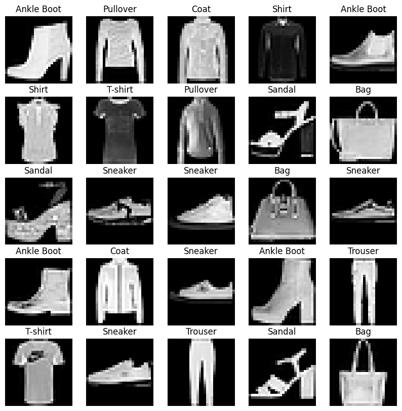

```python
import matplotlib.pyplot as plt

labels_map={
    0: 'T-shirt',
    1: 'Trouser',
    2: 'Pullover',
    3: 'Dress',
    4: 'Coat',
    5: 'Sandal',
    6: 'Shirt',
    7: 'Sneaker',
    8: 'Bag',
    9: 'Ankle Boot',
}

figure = plt.figure(figsize = (10,10))
cols, rows = 5, 5

for i in range (1, cols*rows + 1):
    sample_idx = torch.randint(len(train_data), size = (1,)).item()
    #print(sample_idx)   # some random chosen indexes from dataset
    image, label = train_data[sample_idx]     # each image has 2d array representing image plus nmbr ot eticquete = class
    figure.add_subplot(rows, cols, i)
    plt.title(labels_map[label])
    plt.axis('off')
    plt.imshow(image.squeeze(), cmap='gray')
plt.show()
```

```python
import numpy as np
print(len(train_data[0])) #obrazek z etykieta
print(len(train_data[0][0]))  # tablica obrazka
print(len(train_data[0][0][0]))   #wiersze obrazka
print(len(train_data[0][0][0][0]))  #dopiero tutaj kolumny
```

```
2
1
28
28
```

# Budujemy modele

Druga sieć ma taką samą ilość warstw ale filtry zwracają inne wartości kanałów oraz liczba neuronów w warstwach liniowych jest inna w porównaniu do modelu pierwszego.  
Trzeci model zawiera o jedną wartwę konwolucyjną więcej or pierwszego modelu.

```python
import torch.nn as nn
import torch.nn.functional as F

class Net1(nn.Module):
    def __init__(self):
        super().__init__()
        self.conv1 = nn.Conv2d(1, 6, 5)           # input channel size, output channel size, kernel size
        self.pool = nn.MaxPool2d(2, 2)            # kernel size : 2x2
        self.conv2 = nn.Conv2d(6, 16, 5)          # input channel size has to be equal to last output channel size, so in our last conv layer, output is even bigger, and kernel size remains the same
        self.fc1 = nn.Linear(16 * 4 * 4, 120)     # first fully connected layer
        self.fc2 = nn.Linear(120, 84)
        self.fc3 = nn.Linear(84, 10)              # output 10 = 10 classes

    def forward(self, x):
        x = self.pool(F.relu(self.conv1(x)))      # rozmiar: 28-5+1 -> 24 -> /2 ->12
        x = self.pool(F.relu(self.conv2(x)))      # rozmiar 12-5+1 -> 8 -> /2 -> 4 (dlatego w pierwszej linear musimy mieć 4*4*16 channeli)
        x = torch.flatten(x,1)                    # now we need to flatten, -1 - nmbr of betches, potem rozmiar inputu
        x = F.relu(self.fc1(x))
        x = F.relu(self.fc2(x))
        x = self.fc3(x)
        return x

class Net2(nn.Module):
    def __init__(self):
        super().__init__()
        self.conv1 = nn.Conv2d(1, 10, 5)
        self.pool = nn.MaxPool2d(2, 2)
        self.conv2 = nn.Conv2d(10, 20, 5)
        self.fc1 = nn.Linear(20 * 4 * 4, 160)
        self.fc2 = nn.Linear(160, 76)
        self.fc3 = nn.Linear(76, 10)

    def forward(self, x):
        x = self.pool(F.relu(self.conv1(x)))      # 28 -> 12
        x = self.pool(F.relu(self.conv2(x)))      # -> 4
        x = torch.flatten(x,1)
        x = F.relu(self.fc1(x))
        x = F.relu(self.fc2(x))
        x = self.fc3(x)
        return x


class Net3(nn.Module):
    def __init__(self):
        super().__init__()
        self.conv1 = nn.Conv2d(1, 6, 3)
        self.pool = nn.MaxPool2d(2, 2)
        self.conv2 = nn.Conv2d(6, 16, 3)
        self.conv3 = nn.Conv2d(16, 32, 3)
        self.avgpool = nn.AdaptiveAvgPool2d((1, 1))
        self.fc1 = nn.Linear(32, 120)
        self.fc2 = nn.Linear(120, 84)
        self.fc3 = nn.Linear(84, 10)

    def forward(self, x):
        x = self.pool(F.relu(self.conv1(x)))
        #print(x.shape)
        x = self.pool(F.relu(self.conv2(x)))
        #print(x.shape)
        x = self.pool(F.relu(self.conv3(x)))
        #print(x.shape)
        x = torch.flatten(x,1)
        #print(x.shape)
        x = F.relu(self.fc1(x))
        x = F.relu(self.fc2(x))
        x = self.fc3(x)
        return x


net1 = Net1()
net2 = Net2()
net3 = Net3()

x = torch.cuda.current_device()
net1.to(x)
net2.to(x)
net3.to(x)
```

```
Net3(
  (conv1): Conv2d(1, 6, kernel_size=(3, 3), stride=(1, 1))
  (pool): MaxPool2d(kernel_size=2, stride=2, padding=0, dilation=1, ceil_mode=False)
  (conv2): Conv2d(6, 16, kernel_size=(3, 3), stride=(1, 1))
  (conv3): Conv2d(16, 32, kernel_size=(3, 3), stride=(1, 1))
  (avgpool): AdaptiveAvgPool2d(output_size=(1, 1))
  (fc1): Linear(in_features=32, out_features=120, bias=True)
  (fc2): Linear(in_features=120, out_features=84, bias=True)
  (fc3): Linear(in_features=84, out_features=10, bias=True)
)
```

```python
from torch.utils.data import DataLoader

trainloader = DataLoader(train_data, batch_size=64, shuffle=True)
testloader = DataLoader(test_data, batch_size=64, shuffle=True)
```

```python
from torch import optim
optimazer1, optimazer2, optimazer3 = optim.Adam(net1.parameters()),optim.Adam(net2.parameters()),optim.Adam(net3.parameters())
```

```python
def train(net, optimizer, epochs=10):
  cross_entrophy = torch.nn.CrossEntropyLoss()
  loss_history = []
  for epoch in range(epochs):
      running_loss = 0
      for i, data in enumerate(trainloader, 0):
          inputs, labels = data
          inputs,labels = inputs.to(x), labels.to(x)
          optimizer.zero_grad()
          outputs = net(inputs)
          loss = cross_entrophy(outputs, labels)
          loss.backward()
          optimizer.step()
          running_loss += loss.item()
          if i % 200 == 199:
            print(f'Epoka {epoch+1}/{epochs}, funkcja strat: {running_loss / 2000:.3f}')
            loss_history.append(running_loss / 2000)
            running_loss = 0.0
  print('Finished Training')
  return loss_history
```

```python
loss_history_net1 = train(net1, optimazer1)
```

```
Epoka 1/10, funkcja strat: 0.116
Epoka 1/10, funkcja strat: 0.073
Epoka 1/10, funkcja strat: 0.062
Epoka 1/10, funkcja strat: 0.058
Epoka 2/10, funkcja strat: 0.051
Epoka 2/10, funkcja strat: 0.050
Epoka 2/10, funkcja strat: 0.049
Epoka 2/10, funkcja strat: 0.046
Epoka 3/10, funkcja strat: 0.043
Epoka 3/10, funkcja strat: 0.041
Epoka 3/10, funkcja strat: 0.041
Epoka 3/10, funkcja strat: 0.039
Epoka 4/10, funkcja strat: 0.037
Epoka 4/10, funkcja strat: 0.036
Epoka 4/10, funkcja strat: 0.036
Epoka 4/10, funkcja strat: 0.035
Epoka 5/10, funkcja strat: 0.034
Epoka 5/10, funkcja strat: 0.035
Epoka 5/10, funkcja strat: 0.034
Epoka 5/10, funkcja strat: 0.032
Epoka 6/10, funkcja strat: 0.032
Epoka 6/10, funkcja strat: 0.033
Epoka 6/10, funkcja strat: 0.032
Epoka 6/10, funkcja strat: 0.032
Epoka 7/10, funkcja strat: 0.031
Epoka 7/10, funkcja strat: 0.030
Epoka 7/10, funkcja strat: 0.030
Epoka 7/10, funkcja strat: 0.030
Epoka 8/10, funkcja strat: 0.028
Epoka 8/10, funkcja strat: 0.029
Epoka 8/10, funkcja strat: 0.029
Epoka 8/10, funkcja strat: 0.029
Epoka 9/10, funkcja strat: 0.028
Epoka 9/10, funkcja strat: 0.028
Epoka 9/10, funkcja strat: 0.029
Epoka 9/10, funkcja strat: 0.028
Epoka 10/10, funkcja strat: 0.026
Epoka 10/10, funkcja strat: 0.026
Epoka 10/10, funkcja strat: 0.026
Epoka 10/10, funkcja strat: 0.028
Finished Training
```

```python
loss_history_net2 = train(net2, optimazer2)
```

```
Epoka 1/10, funkcja strat: 0.107
Epoka 1/10, funkcja strat: 0.064
Epoka 1/10, funkcja strat: 0.058
Epoka 1/10, funkcja strat: 0.052
Epoka 2/10, funkcja strat: 0.046
Epoka 2/10, funkcja strat: 0.045
Epoka 2/10, funkcja strat: 0.043
Epoka 2/10, funkcja strat: 0.039
Epoka 3/10, funkcja strat: 0.037
Epoka 3/10, funkcja strat: 0.037
Epoka 3/10, funkcja strat: 0.036
Epoka 3/10, funkcja strat: 0.035
Epoka 4/10, funkcja strat: 0.034
Epoka 4/10, funkcja strat: 0.033
Epoka 4/10, funkcja strat: 0.032
Epoka 4/10, funkcja strat: 0.032
Epoka 5/10, funkcja strat: 0.029
Epoka 5/10, funkcja strat: 0.031
Epoka 5/10, funkcja strat: 0.029
Epoka 5/10, funkcja strat: 0.029
Epoka 6/10, funkcja strat: 0.028
Epoka 6/10, funkcja strat: 0.027
Epoka 6/10, funkcja strat: 0.028
Epoka 6/10, funkcja strat: 0.027
Epoka 7/10, funkcja strat: 0.026
Epoka 7/10, funkcja strat: 0.027
Epoka 7/10, funkcja strat: 0.025
Epoka 7/10, funkcja strat: 0.026
Epoka 8/10, funkcja strat: 0.024
Epoka 8/10, funkcja strat: 0.025
Epoka 8/10, funkcja strat: 0.024
Epoka 8/10, funkcja strat: 0.025
Epoka 9/10, funkcja strat: 0.023
Epoka 9/10, funkcja strat: 0.024
Epoka 9/10, funkcja strat: 0.023
Epoka 9/10, funkcja strat: 0.024
Epoka 10/10, funkcja strat: 0.022
Epoka 10/10, funkcja strat: 0.022
Epoka 10/10, funkcja strat: 0.022
Epoka 10/10, funkcja strat: 0.022
Finished Training
```

```python
loss_history_net3 = train(net3, optimazer3)
```

```
Epoka 1/10, funkcja strat: 0.139
Epoka 1/10, funkcja strat: 0.083
Epoka 1/10, funkcja strat: 0.073
Epoka 1/10, funkcja strat: 0.069
Epoka 2/10, funkcja strat: 0.062
Epoka 2/10, funkcja strat: 0.061
Epoka 2/10, funkcja strat: 0.059
Epoka 2/10, funkcja strat: 0.056
Epoka 3/10, funkcja strat: 0.054
Epoka 3/10, funkcja strat: 0.054
Epoka 3/10, funkcja strat: 0.053
Epoka 3/10, funkcja strat: 0.052
Epoka 4/10, funkcja strat: 0.050
Epoka 4/10, funkcja strat: 0.050
Epoka 4/10, funkcja strat: 0.048
Epoka 4/10, funkcja strat: 0.050
Epoka 5/10, funkcja strat: 0.048
Epoka 5/10, funkcja strat: 0.046
Epoka 5/10, funkcja strat: 0.045
Epoka 5/10, funkcja strat: 0.046
Epoka 6/10, funkcja strat: 0.044
Epoka 6/10, funkcja strat: 0.044
Epoka 6/10, funkcja strat: 0.044
Epoka 6/10, funkcja strat: 0.044
Epoka 7/10, funkcja strat: 0.042
Epoka 7/10, funkcja strat: 0.041
Epoka 7/10, funkcja strat: 0.041
Epoka 7/10, funkcja strat: 0.041
Epoka 8/10, funkcja strat: 0.038
Epoka 8/10, funkcja strat: 0.041
Epoka 8/10, funkcja strat: 0.040
Epoka 8/10, funkcja strat: 0.041
Epoka 9/10, funkcja strat: 0.039
Epoka 9/10, funkcja strat: 0.040
Epoka 9/10, funkcja strat: 0.038
Epoka 9/10, funkcja strat: 0.038
Epoka 10/10, funkcja strat: 0.038
Epoka 10/10, funkcja strat: 0.038
Epoka 10/10, funkcja strat: 0.037
Epoka 10/10, funkcja strat: 0.038
Finished Training
```

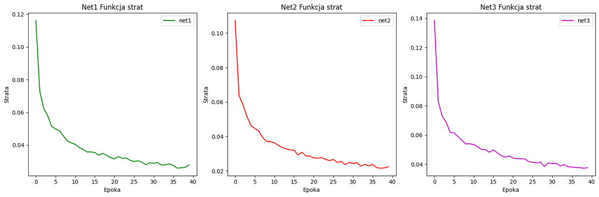

```python
fig, axs = plt.subplots(1, 3, figsize=(15, 5))

axs[0].plot(loss_history_net1,label = 'net1',c='g')
axs[0].set_title('Net1 Funkcja strat')

axs[1].plot(loss_history_net2,label = 'net2',c='r')
axs[1].set_title('Net2 Funkcja strat')

axs[2].plot(loss_history_net3,label = 'net3',c='m')
axs[2].set_title('Net3 Funkcja strat')

for i in range(3):
  axs[i].set_xlabel('Epoka')
  axs[i].set_ylabel('Strata')
  axs[i].legend()
plt.tight_layout()
plt.show()
```

```python
from torchvision.utils import make_grid
from sklearn.metrics import confusion_matrix, ConfusionMatrixDisplay

def evaluation(net):
    correct = 0
    total = 0
    confusion_matrix = np.zeros((10, 10), dtype=int)
    misclassified_images = []
    with torch.no_grad():
        for data in testloader:
            images, labels = data
            images,labels = images.to(x), labels.to(x)
            outputs = net(images)
            _, predicted = torch.max(outputs.data, 1)
            total += labels.size(0)
            correct += (predicted == labels).sum().item()
            for i in range(len(labels)):
                confusion_matrix[labels[i]][predicted[i]] += 1
                if predicted[i] != labels[i] and len(misclassified_images) < 1:     # dodamy jakis jeden obrazek
                    misclassified_images.append((images[i], labels[i], predicted[i]))

    #print(confusion_matrix)
    print(f'Network Accuracy on test images: {100 * correct / total}%')
    plt.figure(figsize=(12, 8))
    ConfusionMatrixDisplay(confusion_matrix,display_labels=labels_map.values()).plot()
    plt.xticks(rotation=45)
    plt.show()

    return misclassified_images[0]
```

```
Network Accuracy on test images: 88.39%
```

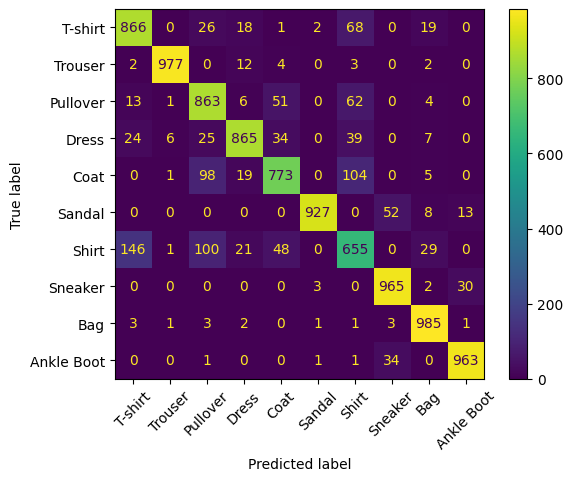

```
Przykładowy pomylony obraz:
```

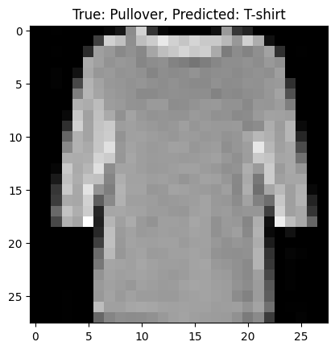

```
Network Accuracy on test images: 90.06%
```

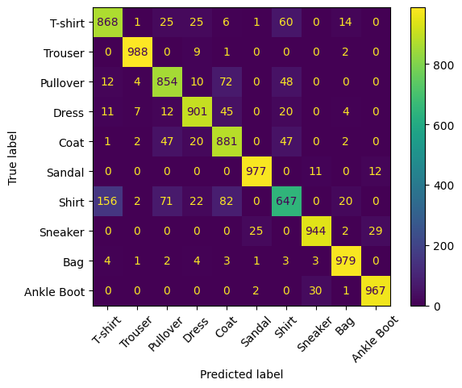

```
Przykładowy pomylony obraz:
```

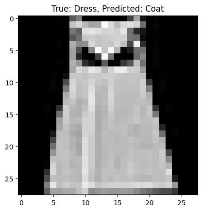

```
Network Accuracy on test images: 85.36%
```

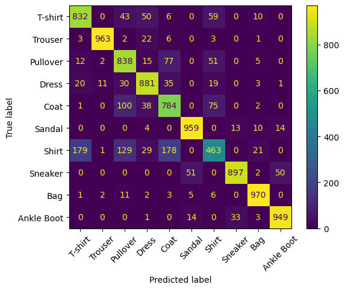

```
Przykładowy pomylony obraz:
```

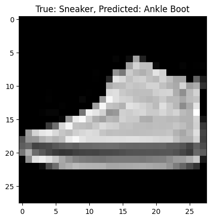

```python
for net in [net1, net2, net3]:
  image, true_label, predicted_label = evaluation(net)
  print('Przykładowy pomylony obraz:')
  plt.imshow(image.cpu().squeeze(), cmap='gray')
  plt.title(f'True: {labels_map[true_label.item()]}, Predicted: {labels_map[predicted_label.item()]}')
  plt.show()
```

## Wnioski

### Pierwszy model

Zwraca bardzo dobre wyniki.

### Drugi model

Wykazał się nieznacznie lepszą wydajnością w porównaniu do modelu 1. Zastosowanie większej liczby neuronów w warstwach liniowych i filtrów zwracających większą wartość kanałów przyczyniło się do delikatnej poprawy wyników. Funkcja strat początkowo osiągała niższe (lepsze) wartości, ale po 10 epokach, wartość przez nią zwracana jest porównywalna dla obu sieci.

### Trzeci model

Po dodaniu kolejnej warstwy konwolucyjnej, trzeci model osiągnął najgorsze wyniki. Funkcja strat zwraca wartości dwukrotnie większe niż w przypadku modelu 2. Dokładność dopasowania etykiet na zbiorze testowym była niższa o 5 punktów procentowych w porównaniu do modelu 2 i o 3 punkty procentowe w porównaniu do modelu 1.

# ZAD 2

Dla jednej wybranej architektury, proszę porównać czas uczenia sieci na CPU i na GPU, do czego mogą Państwo wykorzystać własną kartę NVidii lub zasoby Colaba. W Runtime->Change Runtime Type musi być zaznaczona opcja "T4 GPU".

```python
from time import time
def train_and_time(net, optimizer, device, epochs=10):
  device = torch.device(device)
  net.to(device)
  start_time = time()
  cross_entrophy = torch.nn.CrossEntropyLoss()
  for epoch in range(epochs):
    for i, data in enumerate(trainloader, 0):
      inputs, labels = data
      inputs, labels = inputs.to(device), labels.to(device)
      optimizer.zero_grad()
      outputs = net(inputs)
      loss = cross_entrophy(outputs, labels)
      loss.backward()
      optimizer.step()
      if i % 500 == 499:
        print(f'Epoka {epoch+1}/{epochs}')
  print('Finished Training')
  end_time = time()
  print(f'Czas uczenia na {device}: {end_time - start_time:.2f} sekund')
```

```python
net1 = Net1()
optimizer1 = optim.Adam(net1.parameters())
train_and_time(net1, optimizer1,'cuda')
```

```
Epoka 1/10
Epoka 2/10
Epoka 3/10
Epoka 4/10
Epoka 5/10
Epoka 6/10
Epoka 7/10
Epoka 8/10
Epoka 9/10
Epoka 10/10
Finished Training
Czas uczenia na cuda: 85.70 sekund
```

```python
net1 = Net1()
optimizer1 = optim.Adam(net1.parameters())
train_and_time(net1, optimizer1,'cpu')
```

```
Epoka 1/10
Epoka 2/10
Epoka 3/10
Epoka 4/10
Epoka 5/10
Epoka 6/10
Epoka 7/10
Epoka 8/10
Epoka 9/10
Epoka 10/10
Finished Training
Czas uczenia na cpu: 164.34 sekund
```

## Wnioski

Wykorzystanie GPU z jednostkami CUDA znacząco przyspieszyło proces uczenia sieci neuronowej, skracając czas o prawie 2 razy w porównaniu do CPU. CUDA, dzięki efektywnemu przetwarzaniu macierzy, istotnie wpływa na wydajność obliczeń w warstwach konwolucyjnych.